# $F_{ST}$ within lakes.

J. Ignacio Lucas Lledó & Mar Llaberia-Robledillo

2023-01-09

Species in the same lake are supposed to hybridize occasionally, so that they may share variation along large portions of the genome. That is: the $F_{ST}$ between species in the same lake are expected to be low, in general. But loci that contribute to the adaptation of an ecomorph must remain divergent between ecomorphs in the same lake. In a background of low $F_{ST}$ values, it should be easy to spot the positions with high $F_{ST}$ values.

# Alpine region

I will compare first *C. fatioi* (Felchen ecomorph, Thun and Brienz lakes) with *C. steinmanni* (Balchen ecomorph, in Thun).

```bash
VCF=../2022-04-22/assem2_outfiles/assem2.vcf
FISHDATA=../../data/Fish_clean2.tsv

if [ ! -d FST ]; then mkdir FST; fi

if [ ! -e FST/fatioi-steinmanni.windowed.weir.fst ]; then
   if [ ! -e dirty.recode.vcf ]; then
      vcftools --vcf $VCF \
               --out dirty \
               --remove ../2022-05-04/TheWorst.txt \
               --recode \
               --recode-INFO-all > vcftools.log 2>&1
   fi

   if [ ! -e C.fatioi.txt ]; then
      gawk '($19 == "C.fatioi"){print $1}' $FISHDATA > C.fatioi.txt
   fi

   if [ ! -e C.steinmanni ]; then
      gawk '($19 == "C.steinmanni"){print $1}' $FISHDATA > C.steinmanni.txt
   fi

   vcftools --vcf dirty.recode.vcf \
            --out FST/fatioi-steinmanni \
            --thin 500 \
            --remove-indels \
            --mac 2 \
            --max-alleles 2 \
            --max-missing 1 \
            --max-meanDP 1000 \
            --weir-fst-pop C.fatioi.txt \
            --weir-fst-pop C.steinmanni.txt \
            --fst-window-size 1000000 \
            --fst-window-step  100000 >> vcftools.log 2>&1
fi
```

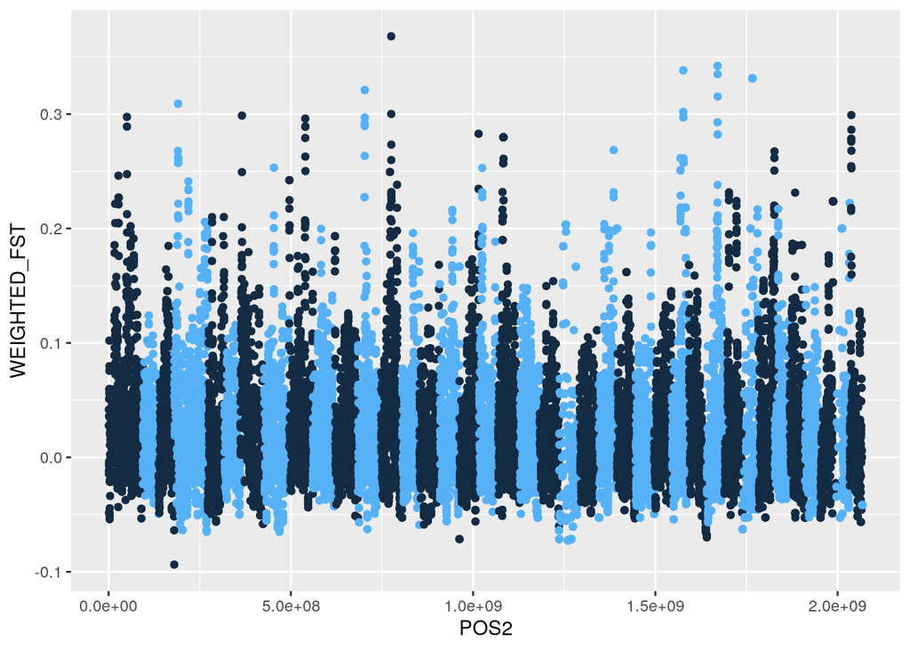

```r
suppressMessages(library(Biostrings))
suppressMessages(library(GenomicRanges))
suppressMessages(library(ggplot2))
ref             <- readDNAStringSet('../../data/reference.fa')
# The names of chromosomes must be only the first word in the fasta name line.
names(ref)      <- sapply(strsplit(names(ref), " "), '[[', 1)
# the refWidth table contains the lengths of chromosomes.
refWidth        <- width(ref)
names(refWidth) <- names(ref)

fst1 <- read.table('FST/fatioi-steinmanni.windowed.weir.fst',
                  header = TRUE, stringsAsFactors = FALSE)
fst1$POS        <- (fst1$BIN_END + fst1$BIN_START) / 2
offset          <- cumsum(refWidth)[1:39]
names(offset)   <- names(ref)[2:40]
offset['LR778253.1'] <- 0
fst1$offset      <- offset[fst1$CHROM]
fst1$POS2        <- fst1$POS + fst1$offset
ChromCol        <- rep(c(1,2), 20)
names(ChromCol) <- names(ref)
fst1$ChromCol    <- ChromCol[fst1$CHROM]
ggplot(data = fst1, mapping = aes(x = POS2, y = WEIGHTED_FST, color = ChromCol)) +
   geom_point() + theme(legend.position="none")
```

The equivalent comparison between a Felchen and a Balchen ecomorph in a different lake is the comparsion of *C. zuerichensis* (Felchen) and *C. duplex* (Balchen), both from the Zurich and Walen lakes. If natural selection targeted the same loci in both lakes to produce the adaptations that define the Felchen and Balchen ecomorphs, then, several windows with a high $F_{ST}$ above should also have a high $F_{ST}$ in the results below. Let's see.

```bash
FISHDATA=../../data/Fish_clean2.tsv

if [ ! -e FST/zuerichensis-duplex.windowed.weir.fst ]; then
   if [ ! -e C.zuerichensis.txt ]; then
      gawk '($19 == "C.zuerichensis"){print $1}' $FISHDATA > C.zuerichensis.txt
   fi

   if [ ! -e C.duplex.txt ]; then
      gawk '($19 == "C.duplex"){print $1}' $FISHDATA > C.duplex.txt
   fi
   vcftools --vcf dirty.recode.vcf \
            --out FST/zuerichensis-duplex \
            --thin 500 \
            --remove-indels \
            --mac 2 \
            --max-alleles 2 \
            --max-missing 1 \
            --max-meanDP 1000 \
            --weir-fst-pop C.zuerichensis.txt \
            --weir-fst-pop C.duplex.txt \
            --fst-window-size 1000000 \
            --fst-window-step  100000 >> vcftools.log 2>&1
fi
```

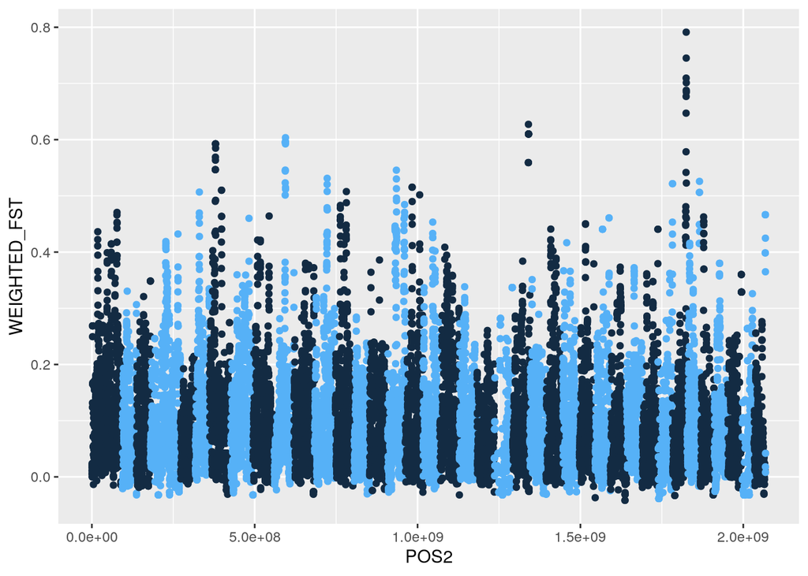

```r
fst2 <- read.table('FST/zuerichensis-duplex.windowed.weir.fst',
                   header = TRUE, stringsAsFactors = FALSE)
fst2$POS        <- (fst2$BIN_END + fst2$BIN_START) / 2
offset          <- cumsum(refWidth)[1:39]
names(offset)   <- names(ref)[2:40]
offset['LR778253.1'] <- 0
fst2$offset     <- offset[fst2$CHROM]
fst2$POS2       <- fst2$POS + fst2$offset
ChromCol        <- rep(c(1,2), 20)
names(ChromCol) <- names(ref)
fst2$ChromCol   <- ChromCol[fst2$CHROM]
ggplot(data = fst2, mapping = aes(x = POS2, y = WEIGHTED_FST, color = ChromCol)) +
   geom_point() + theme(legend.position="none")
```

```r
# Thun-Brienz:
thrs1 <- quantile(fst1$WEIGHTED_FST, probs = 0.995)
f1 <- fst1$WEIGHTED_FST >= thrs1
# Walen-Zurich:
thrs2 <- quantile(fst2$WEIGHTED_FST, probs = 0.995)
f2 <- fst2$WEIGHTED_FST >= thrs2

GR1 <- GRanges(
   seqnames = factor(fst1[f1, 'CHROM']),
   ranges = IRanges(start = fst1[f1, 'BIN_START'],
                    end = fst1[f1, 'BIN_END'],
                    names = paste0(fst1[f1, 'CHROM'], ':',
                                   fst1[f1, 'BIN_START'], '-',
                                   fst1[f1, 'BIN_END'],
                                   sep = '')),
   strand = '+',
   seqinfo = Seqinfo(seqnames = names(ref),
                     seqlengths = width(ref))
)
GR1 <- reduce(GR1)

GR2 <- GRanges(
   seqnames = factor(fst2[f2, 'CHROM']),
   ranges = IRanges(start = fst2[f2, 'BIN_START'],
                    end = fst2[f2, 'BIN_END'],
                    names = paste0(fst2[f2, 'CHROM'], ':',
                                   fst2[f2, 'BIN_START'], '-',
                                   fst2[f2, 'BIN_END'],
                                   sep = '')),
   strand = '+',
   seqinfo = Seqinfo(seqnames = names(ref),
                     seqlengths = width(ref))
)
GR2 <- reduce(GR2)

findOverlaps(GR1, GR2)
```

```
## Hits object with 0 hits and 0 metadata columns:
##    queryHits subjectHits
##    <integer>   <integer>
##   -------
##   queryLength: 25 / subjectLength: 22
```

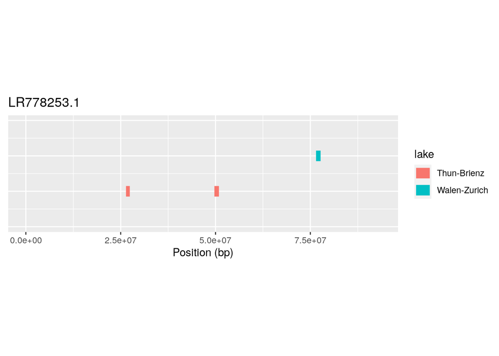

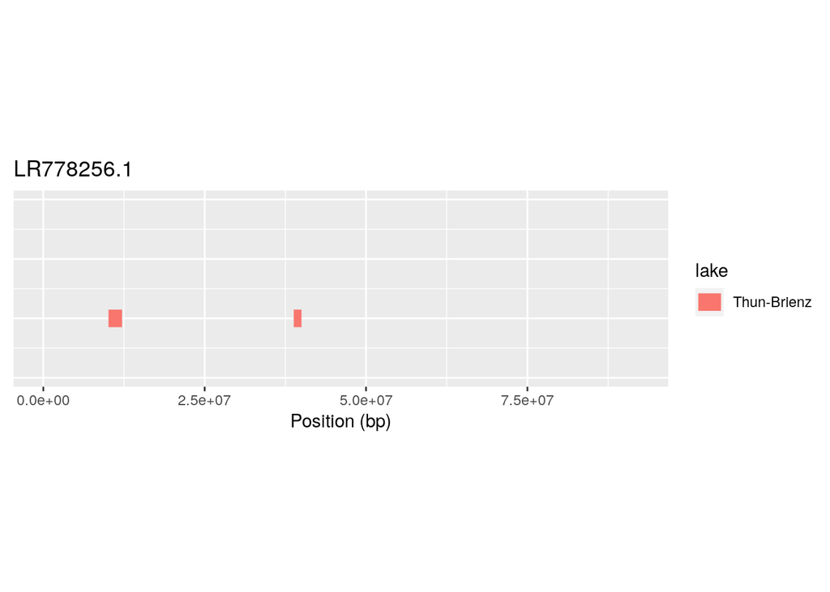

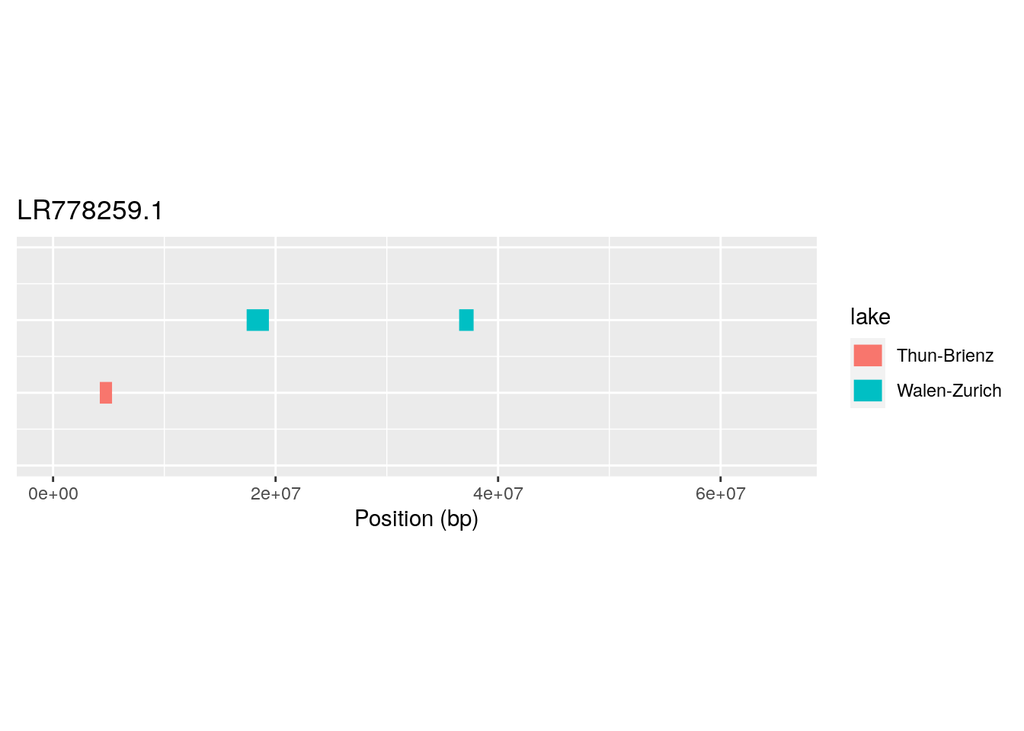

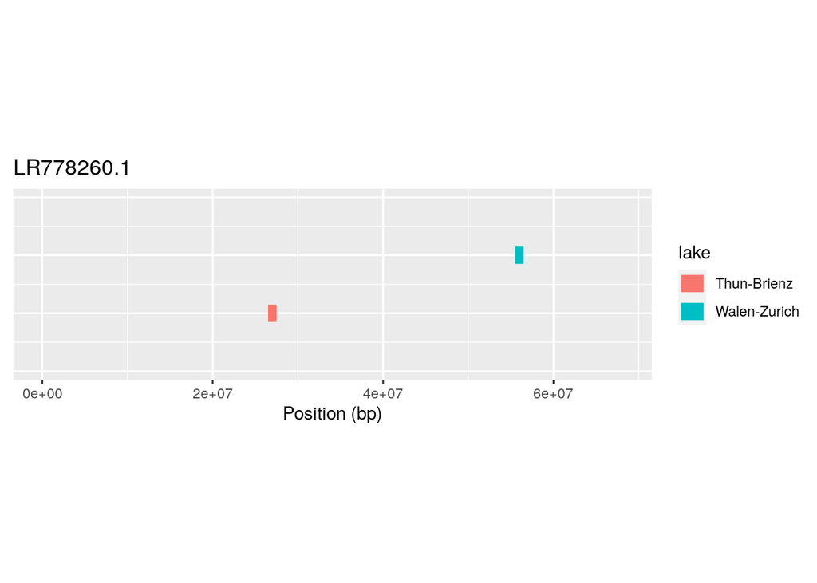

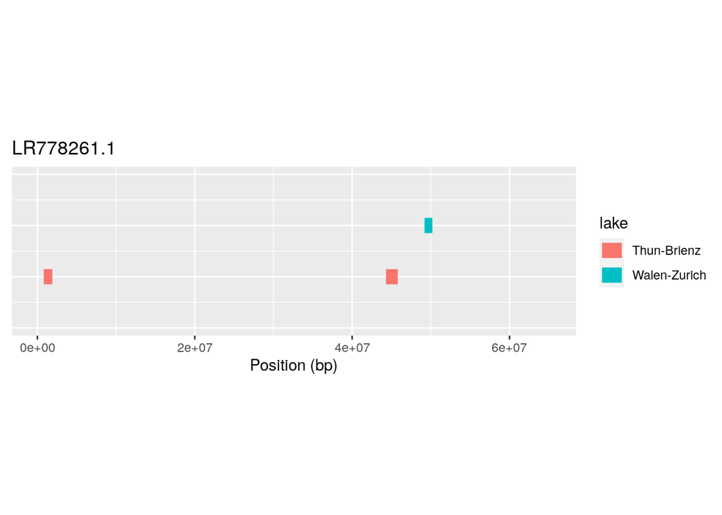

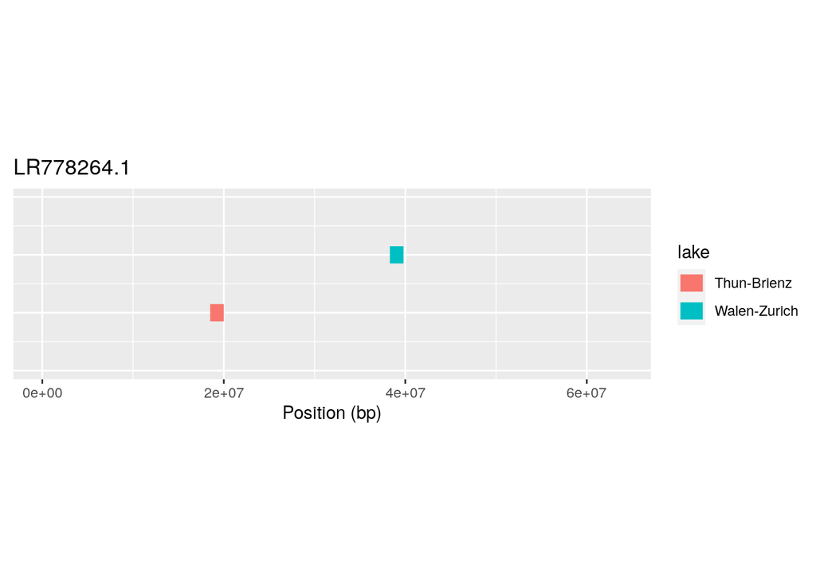

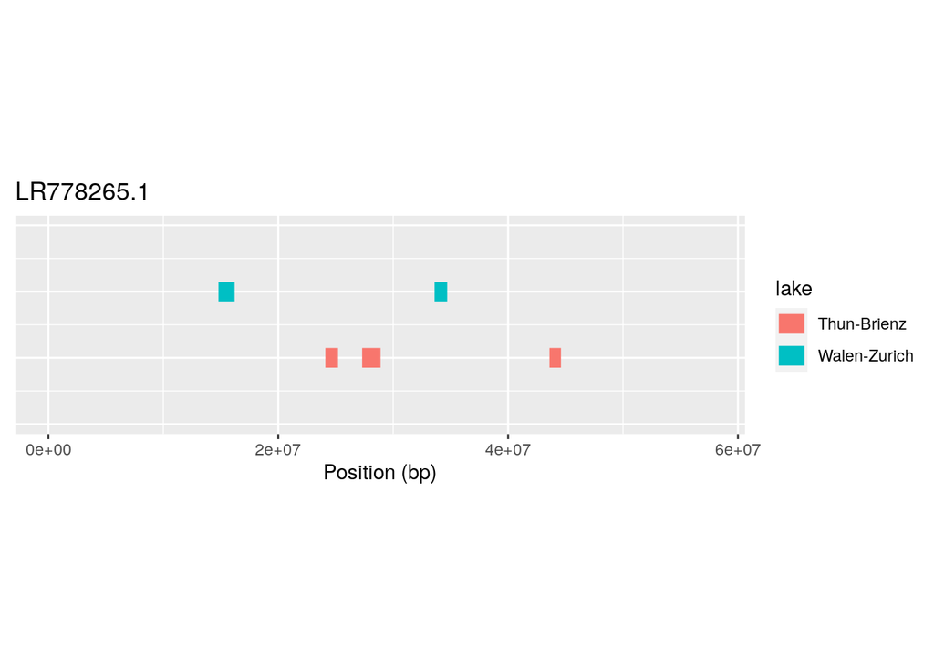

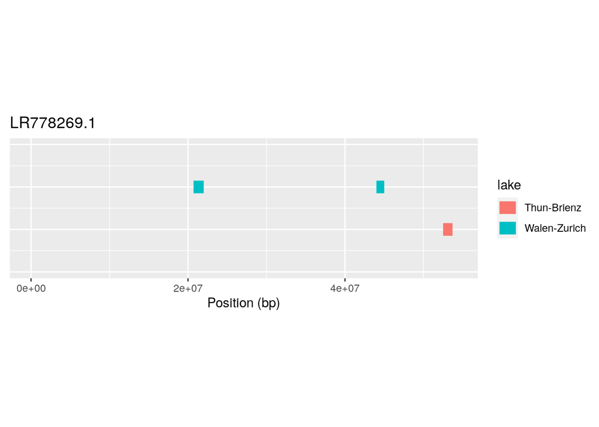

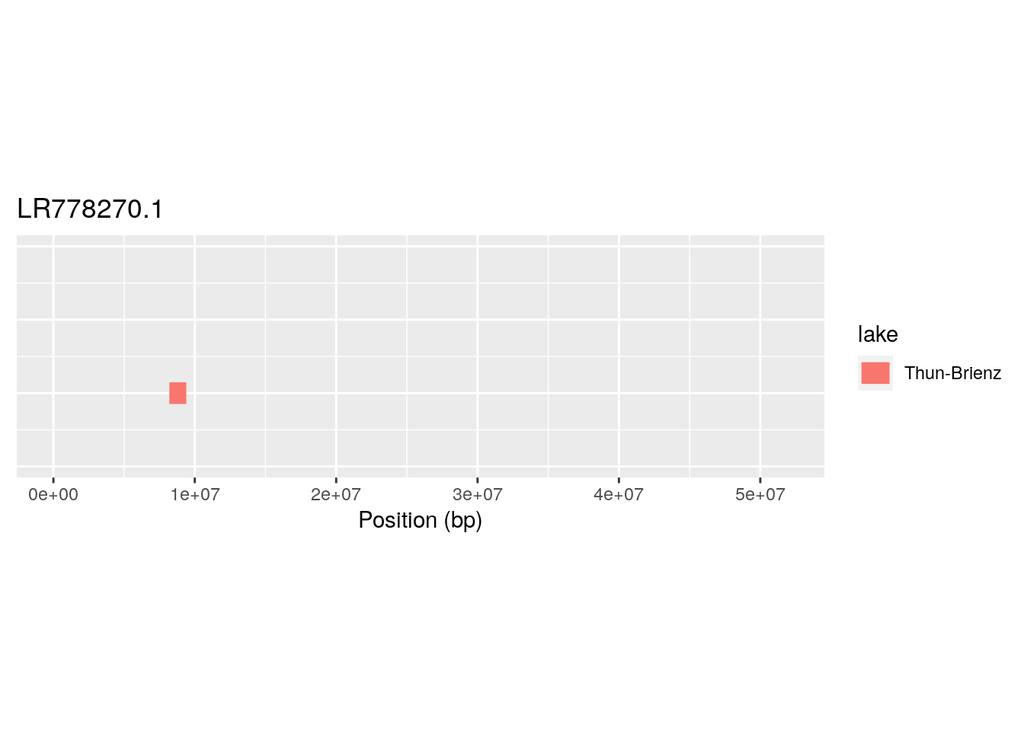

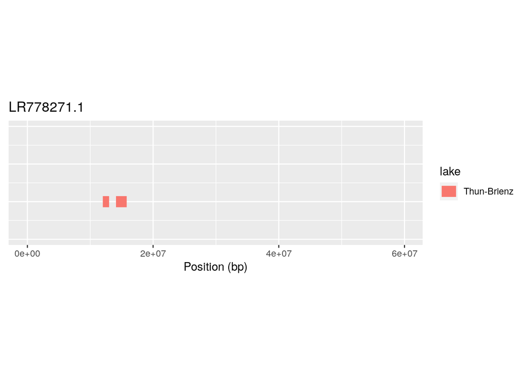

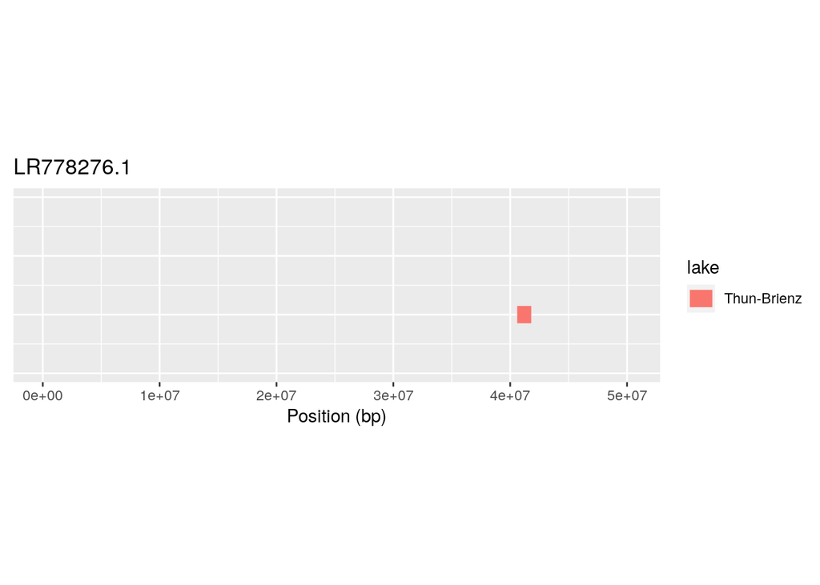

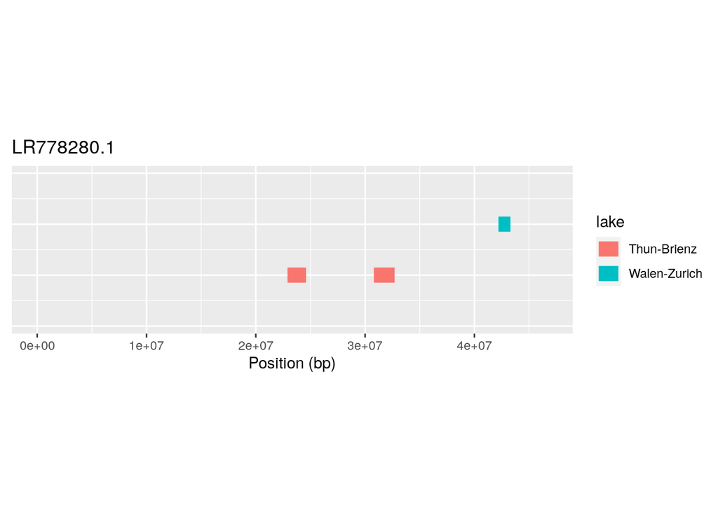

[12 more figures not shown]

```r
GR <- data.frame(
   chr = c(seqnames(GR1), seqnames(GR2)),
   start = c(start(GR1), start(GR2)),
   end = c(end(GR1), end(GR2)),
   lake = c(rep('Thun-Brienz', length(GR1)),
            rep('Walen-Zurich', length(GR2))),
   height = c(rep(1, length(GR1)),
              rep(2, length(GR2)))
)

for (chr in unique(GR$chr)) {
   f <- GR$chr == chr
   p <- ggplot(data = GR[f,],
               mapping = aes(x = start,
                             y = height,
                             xend = end,
                             yend = height,
                             color = lake)) +
      geom_segment(size = 5) +
      ylim(0,3) +
      xlim(0, width(ref[chr])) +
      theme(aspect.ratio = 0.3,
            axis.text.y = element_blank(),
            axis.line.y = element_blank(),
            axis.title.y = element_blank(),
            axis.ticks.y = element_blank()) +
      ggtitle(chr) + xlab('Position (bp)')
   print(p)
}
```

# Arctic region

First, I will compare P and L ecomorphs of lake SUO. I will recover of the text files created in the previous folder (2022-12-23) for the estimation.

```bash
if [ ! -e FST/P-L-SUO.windowed.weir.fst ]; then
   P=../2022-12-23/SUO_P.txt
   L=../2022-12-23/SUO_L.txt

   vcftools --vcf dirty.recode.vcf \
            --out FST/P-L-SUO \
            --thin 500 \
            --remove-indels \
            --mac 2 \
            --max-alleles 2 \
            --max-missing 1 \
            --max-meanDP 1000 \
            --weir-fst-pop $P \
            --weir-fst-pop $L \
            --fst-window-size 1000000 \
            --fst-window-step  100000
fi
```

```
##
## VCFtools - 0.1.17
## (C) Adam Auton and Anthony Marcketta 2009
##
## Parameters as interpreted:
##  --vcf dirty.recode.vcf
##  --fst-window-size 1000000
##  --fst-window-step 100000
##  --weir-fst-pop ../2022-12-23/SUO_P.txt
##  --weir-fst-pop ../2022-12-23/SUO_L.txt
##  --keep ../2022-12-23/SUO_P.txt
##  --keep ../2022-12-23/SUO_L.txt
##  --mac 2
##  --max-alleles 2
##  --max-meanDP 1e+03
##  --thin 500
##  --max-missing 1
##  --out FST/P-L-SUO
##  --remove-indels
##
## Keeping individuals in 'keep' list
## After filtering, kept 60 out of 271 Individuals
## Outputting Windowed Weir and Cockerham Fst estimates.
## Weir and Cockerham mean Fst estimate: 0.070818
## Weir and Cockerham weighted Fst estimate: 0.10858
## After filtering, kept 16287 out of a possible 879238 Sites
## Run Time = 44.00 seconds
```

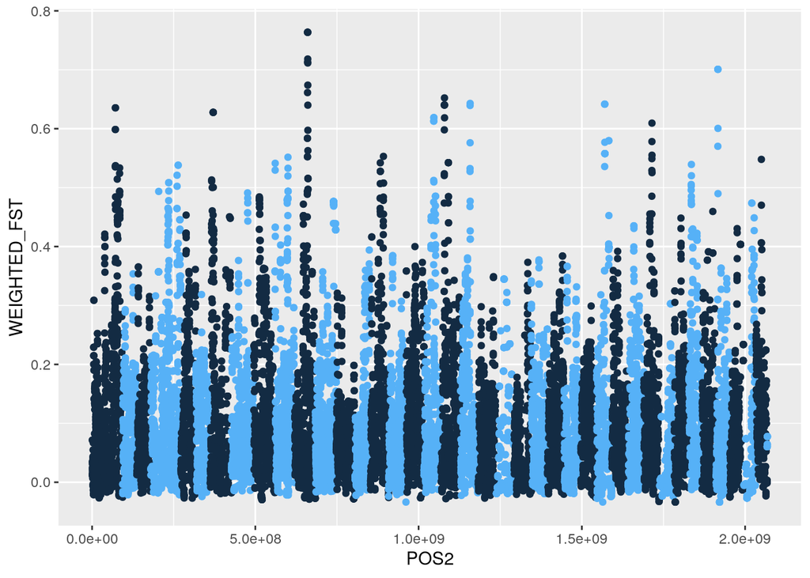

```r
fst3 <- read.table('FST/P-L-SUO.windowed.weir.fst',
                  header = TRUE, stringsAsFactors = FALSE)
fst3$POS    <- (fst3$BIN_END + fst3$BIN_START) / 2
offset     <- cumsum(refWidth)[1:39]
names(offset) <- names(ref)[2:40]
offset['LR778253.1'] <- 0
fst3$offset <- offset[fst3$CHROM]
fst3$POS2 <- fst3$POS + fst3$offset
ChromCol <- rep(c(1,2), 20)
names(ChromCol) <- names(ref)
fst3$ChromCol <- ChromCol[fst3$CHROM]
ggplot(data = fst3, mapping = aes(x = POS2, y = WEIGHTED_FST, color = ChromCol)) +
   geom_point() + theme(legend.position="none")
```

Second, I'm goingo to compare P and L of lake LAN. The same as above.

```bash
if [ ! -e FST/P-L-LAN.windowed.weir.fst ]; then
   P=../2022-12-23/LAN_P.txt
   L=../2022-12-23/LAN_L.txt

   vcftools --vcf dirty.recode.vcf \
            --out FST/P-L-LAN \
            --thin 500 \
            --remove-indels \
            --mac 2 \
            --max-alleles 2 \
            --max-missing 1 \
            --max-meanDP 1000 \
            --weir-fst-pop $P \
            --weir-fst-pop $L \
            --fst-window-size 1000000 \
            --fst-window-step  100000
fi
```

```
##
## VCFtools - 0.1.17
## (C) Adam Auton and Anthony Marcketta 2009
##
## Parameters as interpreted:
##  --vcf dirty.recode.vcf
##  --fst-window-size 1000000
##  --fst-window-step 100000
##  --weir-fst-pop ../2022-12-23/LAN_P.txt
##  --weir-fst-pop ../2022-12-23/LAN_L.txt
##  --keep ../2022-12-23/LAN_P.txt
##  --keep ../2022-12-23/LAN_L.txt
##  --mac 2
##  --max-alleles 2
##  --max-meanDP 1e+03
##  --thin 500
##  --max-missing 1
##  --out FST/P-L-LAN
##  --remove-indels
##
## Keeping individuals in 'keep' list
## After filtering, kept 48 out of 271 Individuals
## Outputting Windowed Weir and Cockerham Fst estimates.
## Weir and Cockerham mean Fst estimate: 0.022231
## Weir and Cockerham weighted Fst estimate: 0.030238
## After filtering, kept 20533 out of a possible 879238 Sites
## Run Time = 43.00 seconds
```

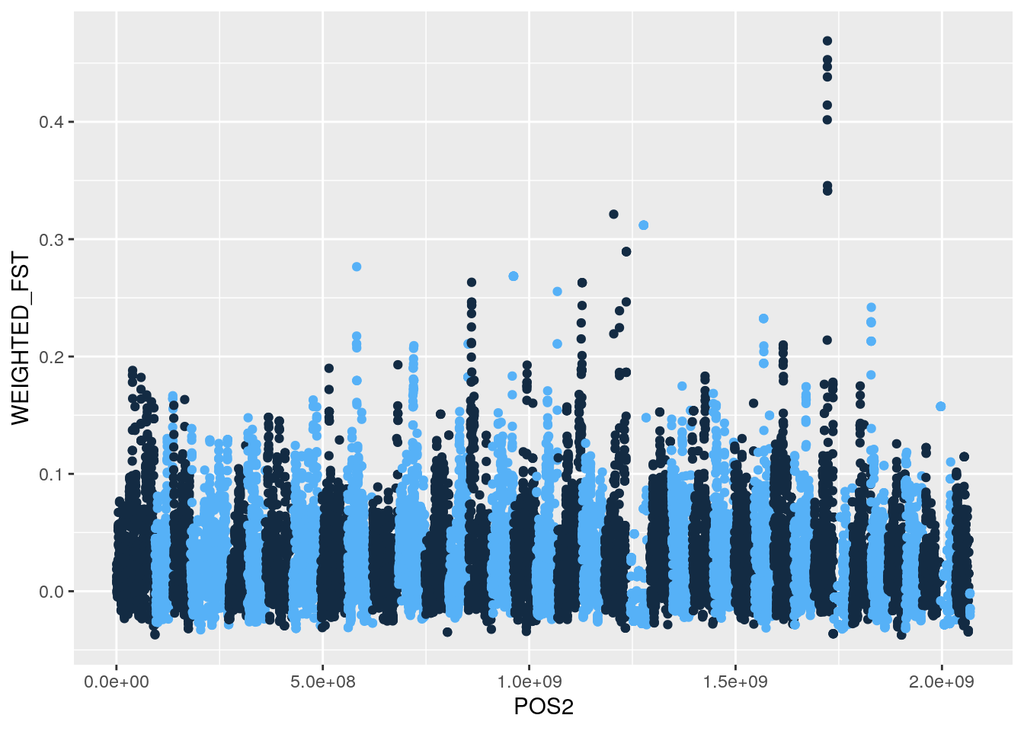

```r
fst4 <- read.table('FST/P-L-LAN.windowed.weir.fst',
                  header = TRUE, stringsAsFactors = FALSE)
fst4$POS    <- (fst4$BIN_END + fst4$BIN_START) / 2
offset     <- cumsum(refWidth)[1:39]
names(offset) <- names(ref)[2:40]
offset['LR778253.1'] <- 0
fst4$offset <- offset[fst4$CHROM]
fst4$POS2 <- fst4$POS + fst4$offset
ChromCol <- rep(c(1,2), 20)
names(ChromCol) <- names(ref)
fst4$ChromCol <- ChromCol[fst4$CHROM]
ggplot(data = fst4, mapping = aes(x = POS2, y = WEIGHTED_FST, color = ChromCol)) +
   geom_point() + theme(legend.position="none")
```

```r
# SUO:
thrs3 <- quantile(fst3$WEIGHTED_FST, probs = 0.995)
f3 <- fst3$WEIGHTED_FST >= thrs3
# LAN:
thrs4 <- quantile(fst4$WEIGHTED_FST, probs = 0.995)
f4 <- fst4$WEIGHTED_FST >= thrs4

GR3 <- GRanges(
   seqnames = factor(fst3[f3, 'CHROM']),
   ranges = IRanges(start = fst3[f3, 'BIN_START'],
                    end = fst3[f3, 'BIN_END'],
                    names = paste0(fst3[f3, 'CHROM'], ':',
                                   fst3[f3, 'BIN_START'], '-',
                                   fst3[f3, 'BIN_END'],
                                   sep = '')),
   strand = '+',
   seqinfo = Seqinfo(seqnames = names(ref),
                     seqlengths = width(ref))
)
GR3 <- reduce(GR3)

GR4 <- GRanges(
   seqnames = factor(fst4[f4, 'CHROM']),
   ranges = IRanges(start = fst4[f4, 'BIN_START'],
                    end = fst4[f4, 'BIN_END'],
                    names = paste0(fst4[f4, 'CHROM'], ':',
                                   fst4[f4, 'BIN_START'], '-',
                                   fst4[f4, 'BIN_END'],
                                   sep = '')),
   strand = '+',
   seqinfo = Seqinfo(seqnames = names(ref),
                     seqlengths = width(ref))
)
GR4 <- reduce(GR4)

findOverlaps(GR3, GR4)
```

```
## Hits object with 0 hits and 0 metadata columns:
##    queryHits subjectHits
##    <integer>   <integer>
##   -------
##   queryLength: 23 / subjectLength: 20
```

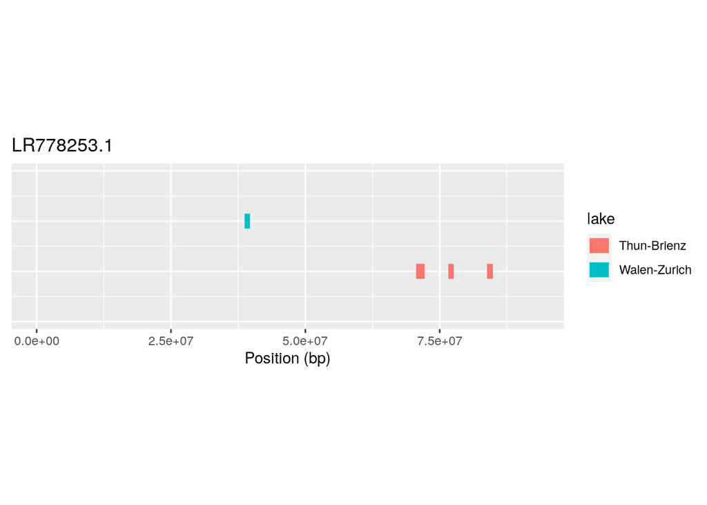

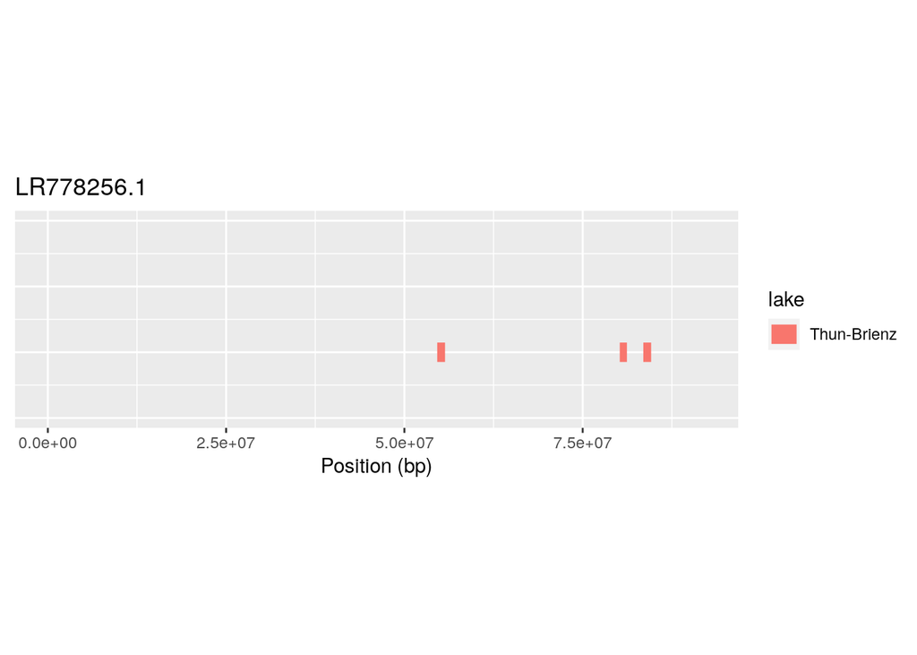

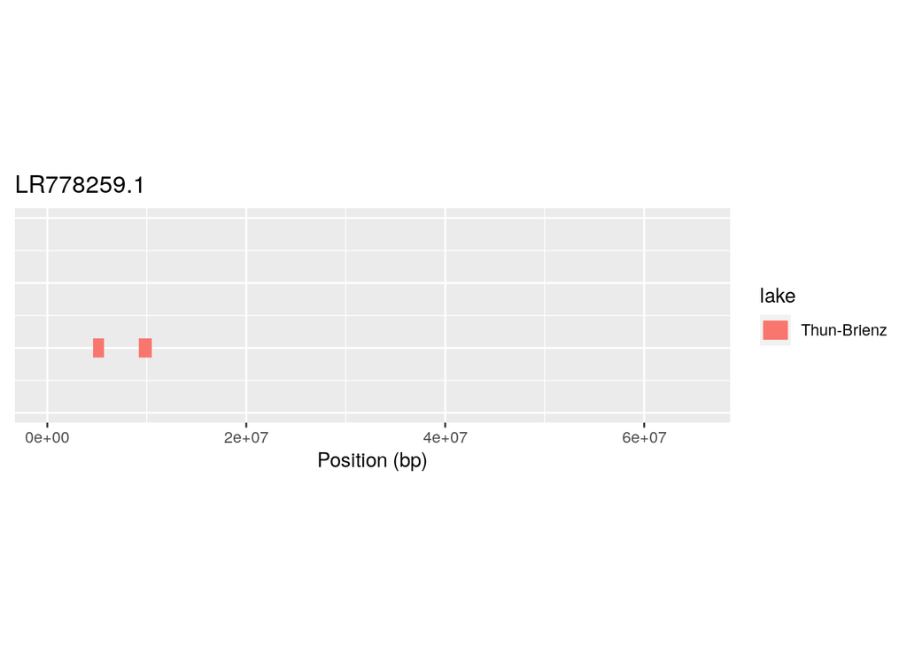

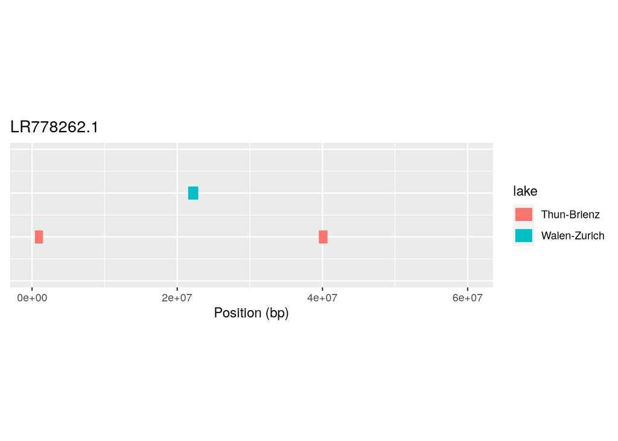

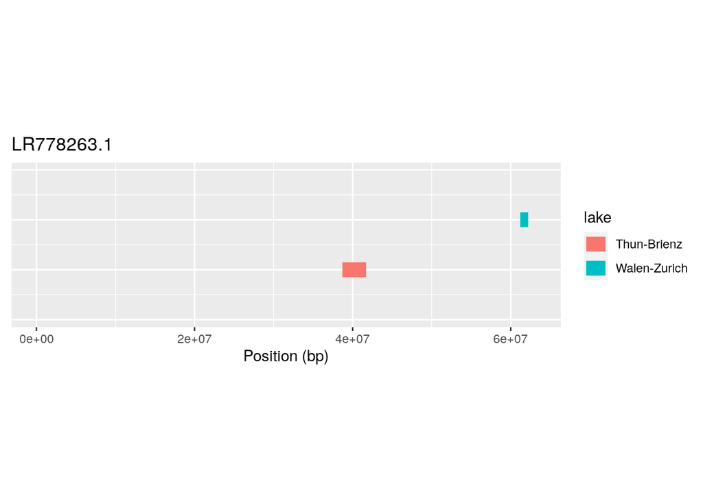

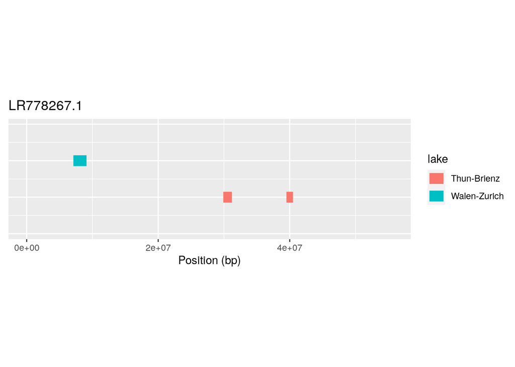

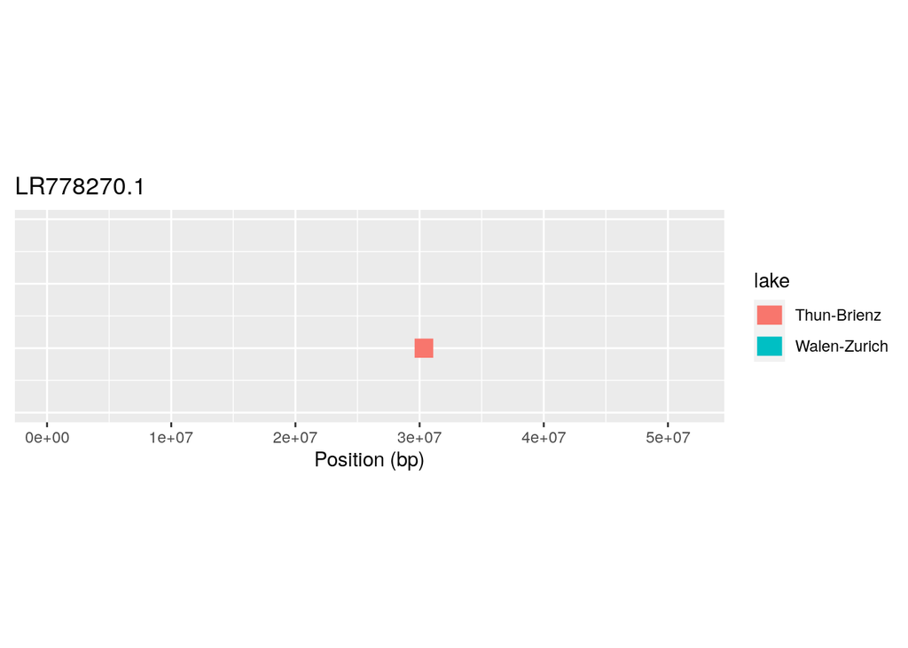

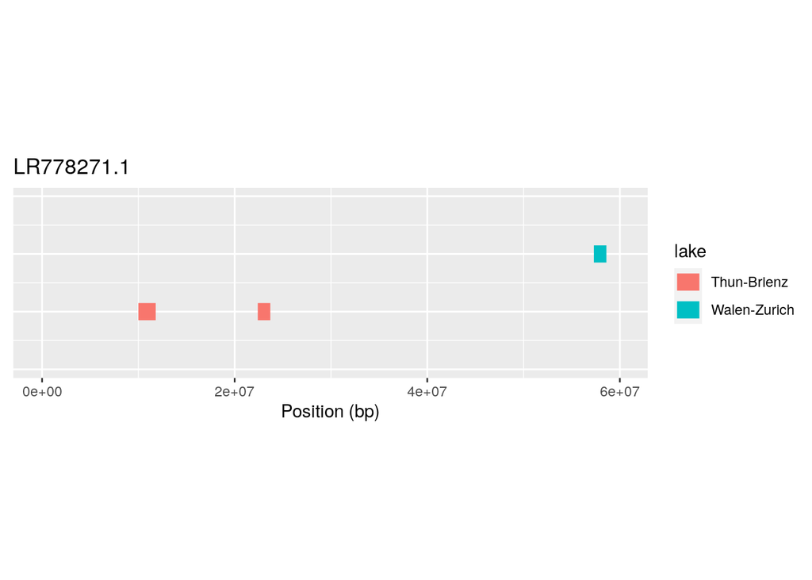

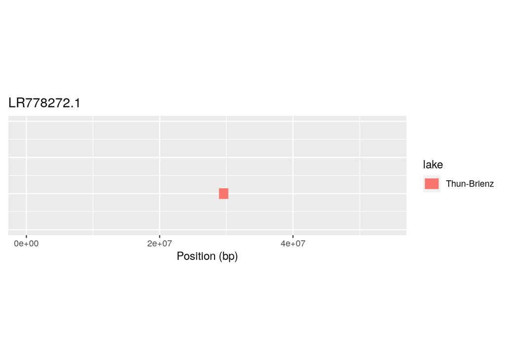

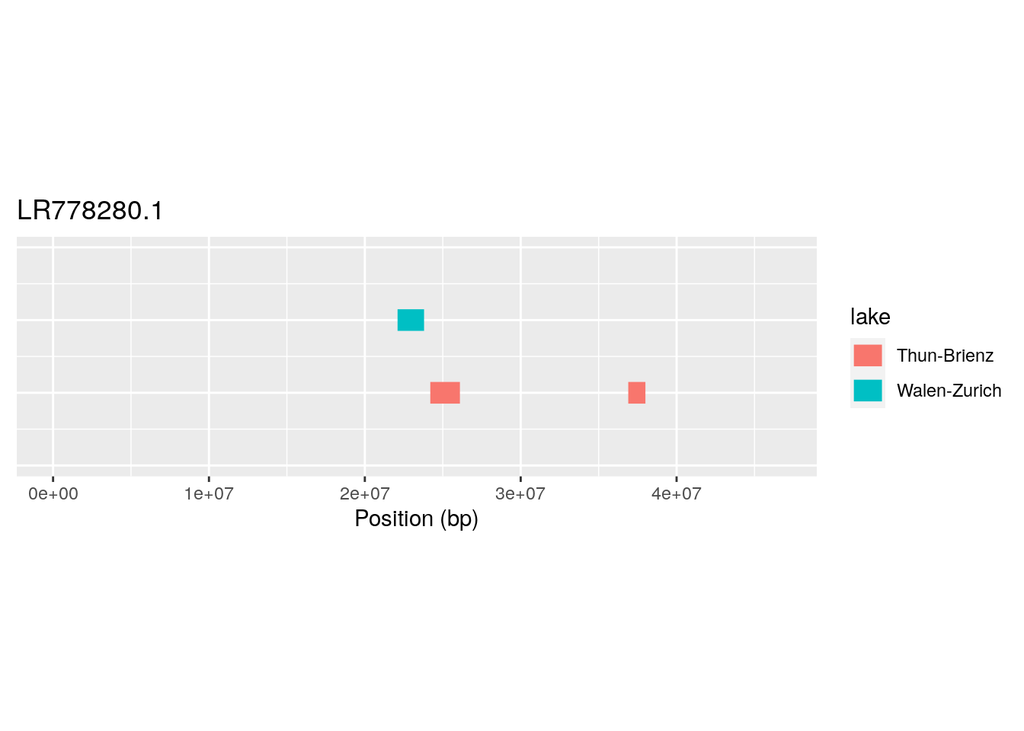

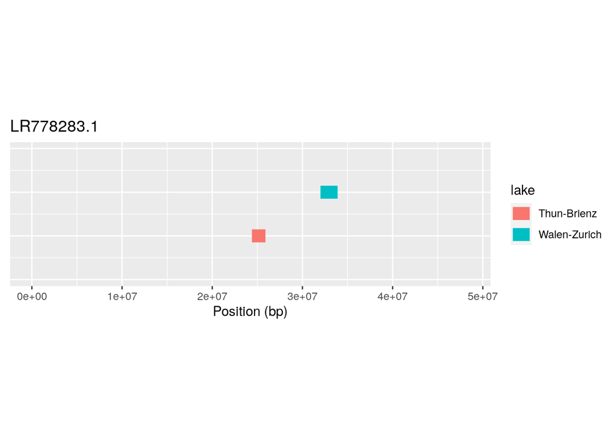

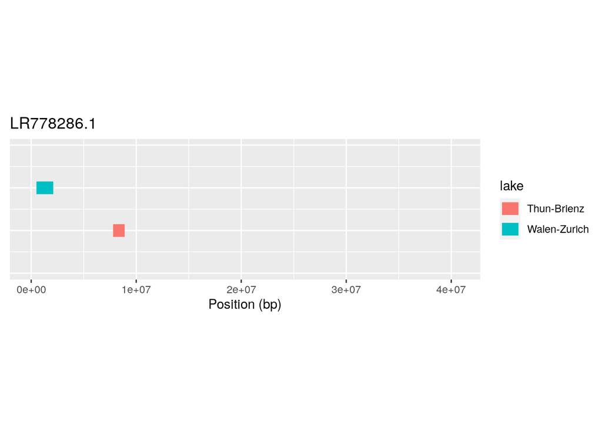

[10 more figures not shown]

```r
GRn <- data.frame(
   chr = c(seqnames(GR3), seqnames(GR4)),
   start = c(start(GR3), start(GR4)),
   end = c(end(GR3), end(GR4)),
   lake = c(rep('Thun-Brienz', length(GR3)),
            rep('Walen-Zurich', length(GR4))),
   height = c(rep(1, length(GR3)),
              rep(2, length(GR4)))
)

for (chr in unique(GRn$chr)) {
   f <- GRn$chr == chr
   p <- ggplot(data = GRn[f,],
               mapping = aes(x = start,
                             y = height,
                             xend = end,
                             yend = height,
                             color = lake)) +
      geom_segment(size = 5) +
      ylim(0,3) +
      xlim(0, width(ref[chr])) +
      theme(aspect.ratio = 0.3,
            axis.text.y = element_blank(),
            axis.line.y = element_blank(),
            axis.title.y = element_blank(),
            axis.ticks.y = element_blank()) +
      ggtitle(chr) + xlab('Position (bp)')
   print(p)
}
```